# Quantifying the Impact of Unexpected Receiver Separation

Will Hoover, J.P. Daliere, Roy Son

2025-12-02

## Executive Report

When considering how likely an on-target pass is to be completed, separation between the receiver and defender seems a natural predictor. However, raw separation at a time-frame fails to account for the context of the play, and how open a receiver is expected to be. Furthermore, can we quantify at which points in the route receivers are more open that what is expected? Are receivers more likely to catch a pass at these points? Does this difference between observed and expected separation bring significant contribution to how many points are expected to be scored on a given play?

To answer this question, two statistical models were built on the NFL’s tracking data, which records information about players on the field ten times per second. The models were built using Extreme Gradient Boosting, a statistical model which attempts to minimize the difference between actual and predicted values through a series of decision trees. The first model estimates the expected separation between a receiver and the closest defensive back at every frame. based on measurable attributes such as a players position, speed, acceleration, route type and more. From this expected separation value, a metric called Separation Over Expected (SOE) was created, which measures how open a receiver was compared to how open they were expected to be to the nearest defender, effectively recording the unexpected separation generated by a receivers movements during a route.

Using the results of both models, a TV replay tool was also created to visualize the relationship between SOE and Catch Probability, an animation that displays receiver and defender position on the field while also showing SOE and Catch Probability simultaneously. In adjunct with live replay, it displays how SOE can explain sudden player movements on the field.

Ultimately, a modest yet significant positive relationship was identified between both SOE and Catch Probability, and SOE and EPA, indicating that not only does unexpected changes in movement that result in separation contribute to actually completing a route, but to the teams chance of scoring over the course of that drive. Future development will account for multiple defenders guarding a receiver, as well as giving more weight to SOE created near the time of pass arrival.

## Technical Report

### Question and Motivation

When considering the likelihood that a catch is made given that the pass is catch-able, the openness of the targeted receiver is a natural and significant factor in estimating this probability at that single moment in time. However, this observed raw separation value doesn’t account for the context of what happened prior to observe that separation. For example, a player could have executed a skill move or had a sudden burst of speed, or a defensive back could have lost turned the wrong direction and lost sight of the receiver. Sometimes, receivers are intentionally left open by defenders as part of zone coverage schemes, or are ignored due to a receivers position on the field. There are many other factors that influence how open a receiver is, which begs the following question.

Given what has already happened prior in a play, and that receivers and defenders have certain measurable attributes such as their position on the field, speed, the route they ran, and but not up to the coverage of the defense, how open should that player have been? Furthermore, if a player is expected to be open by a certain amount compared to their observed openness, how does this value affect the probability of a catch being completed?

Using this intuition, we will attempt to compute the expected separation between a route-runner and a defender based on the provided tracking data, while then comparing this result to observed receiver separation to obtain a metric of how well a receiver gets open relative to this expectation, simply called Separation over Expected (SOE). After this metric is computed, we will attempt to build a catch probability model based on the newly created SOE metric as well as the features that go into producing the metric itself.

We also will observe and identify relationships between SOE and quantitative factors such as Expected Points Added (EPA), and information about the specific route such as route type and defensive coverage scheme.

### Data Loading/Cleaning

To efficiently perform analysis across all weeks of interest, the input and output data frames must be combined. However, before the individual weeks were joined, certain time-frame invariant variables from the supplementary data set and input data frames must be appended to the output data frames, so the relationship between SOE and catch probability can be inspected across multiple levels.

Input/Output data was loaded in list format for future convenience.

```r
Supplementary = read_csv("supplementary_data.csv")
weeks = 1:18

list_of_input = lapply(weeks, function(w) read_csv(paste0("input_2023_w", sprintf("%02d", w), ".csv")))

list_of_output = lapply(weeks, function(w) read_csv(paste0("output_2023_w", sprintf("%02d", w), ".csv")))
```

We define a helper function that automatically appends the relevant variables from the input and supplementary data sets to the output data sets. Only time invariant variables that don’t change during the play and individual 0.1 second frames are selected.

```r
join_output = function(output_df, input_df, supp) {

  output_mod = output_df %>%
    left_join(
      input_df %>%
        select(game_id, play_id, nfl_id, frame_id,
               play_direction, absolute_yardline_number,
               player_name, player_height, player_weight,
               player_birth_date, player_position, player_side,
               player_role, num_frames_output, ball_land_x, ball_land_y),
      by = c("game_id", "play_id", "nfl_id", "frame_id")
    ) %>%
    left_join(
      supp %>%
        select(game_id, play_id, quarter, down, yards_to_go,
               possession_team, defensive_team, offense_formation,
               route_of_targeted_receiver, team_coverage_man_zone,
               team_coverage_type, yards_gained, expected_points_added, pass_result),
      by = c("game_id", "play_id")
    )

  output_mod
}
```

Helper function to append relevant variables from the supplementary data frame to the input data frame.

```r
join_input = function(input_df, supp) {

  input_mod = input_df %>%
    left_join(
      supp %>%
        select(game_id, play_id, week, quarter, down, yards_to_go,
               possession_team, defensive_team, offense_formation,
               route_of_targeted_receiver, team_coverage_man_zone,
               team_coverage_type, yards_gained, expected_points_added, pass_result),
      by = c("game_id", "play_id")
    )

  input_mod
}
```

The process is repeated for each week 1-18, results are binded to a larger, grand data frame.

```r
outputs = list()

for (i in 1:18) {
  outputs[[i]] = join_output(list_of_output[[i]], list_of_input[[i]], Supplementary)
}
Output = bind_rows(outputs)
```

```r
inputs = list()

for (i in 1:18) {
  inputs[[i]] = join_input(list_of_input[[i]], Supplementary)
}

Input = bind_rows(inputs)
```

Converted into data frames only

```r
output_df = as.data.frame(Output)
input_df = as.data.frame(Input)
```

Files saved/loaded as csv for knitting convenience

```r
write_csv(output_df, file = "C:/Users/willh/OneDrive/Documents/STAT 479/Project 3/output.csv")
write_csv(input_df, file = "C:/Users/willh/OneDrive/Documents/STAT 479/Project 3/input.csv")
```

```r
Output = readr::read_csv(file = "C:/Users/willh/OneDrive/Documents/STAT 479/Project 3/output.csv")
Input = readr::read_csv(file = "C:/Users/willh/OneDrive/Documents/STAT 479/Project 3/input.csv")
```

### Separation over Expected and Definitions

Here we formally define the Separation over Expected metric (SOE) for quantifying how open a receiver is relative to how open the receiver was expected to be based on a certain set of variables. We also define other useful metrics and definitions used throughout the analysis.

SOE is defined as the difference between the recorded distance between a receiver and a defensive back of interest at a specific time and an expected distance between the two players.

$$SOE = Actual\space Separation -
Exepected \space Seperation$$

Actual Separation is computed using standard Euclidean straight line distance between the receiver and nearest defender based on our data at each frame, as we have access to the exact position of both the receivers and defenders of interest at in 10 frames per second. This value is subject to change as only the closest defender is considered.

$$Actual \space Separation =
\sqrt{(x_{reciever} - x_{defender})^2 + (y_{reciever} -
y_{defender})^2}$$

Expected separation is defined as the expected separation between the receiver and defender based on our observed data.

$$Expected \space Separation =
\mathbb{E}[separation|data]$$
This expected separation value is to be estimated by some distribution $f$, which in this case will be estimated using XGBoost, a machine learning technique that minimizes pseudo-residuals.

Expected Points Added (EPA) is a value that represents how much value the results of a play increase or decrease the likelihood of a team scoring on a possession. It is calculated by subtracting the difference of Expected Points between two successive plays, and the Expected Points on a play is computed based historical data given on a teams starting yard line, down, quarter, and time remaining in the quarter. The potential for a relationship between EPA and SOE will be explored later in the analysis.

$$EPA = Expected \space Points \space
Before \space Play - Expected \space Points \space After \space
Play$$

We also define model performance metrics to quantify the accuracy of predicted separation values compared to what was observed.

Root Mean Squared Error (RMSE): RMSE measures how far away the models predictions are from the observed outcomes, by taking the average of squared residuals before taking the square root. The square both converts each residual into positive terms while also penalizing more extreme residuals.

$$RMSE =
\sqrt{\frac{\sum_{i=1}^{n}{(\hat{y}_i - y_i)^2}}{n}}$$

Mean Absolute Error (MAE): MAE measures the average of the absolute difference between actual and predicted values.

$$MAE = \frac{1}{n}\sum_{i=1}^{n}|
y_i-\hat{y}_i|$$

Log-Loss: Log-Loss punishes binary classification forecasts forecasts that are very wrong. For example, if the model predicts that the probability of pass being completed in is 95%, but in reality the pass was incomplete, then the “penalty” for miss classifying by a wide margin is large. Models with lower log loss scores tend to make less “extremely wrong” predictions.

$$\textrm{LogLoss} = -1 \times \sum_{i =
1}^{n}{\left[ y_{i} \times \log(\hat{p}_{i}) + (1 -
y_{i})\times\log(1-\hat{p}_{i})\right]}$$

The SOE metric is based on how much open space the receiver achieves relative to model expectations. To build that model, we must first measure actual separation at every frame.

“Input” data frame contains the role labels assigned by tracking staff. We filter to retain exactly one targeted receiver per play and all defensive players assigned to coverage. This process ensures all calculated separations are relevant at the intended pass outcome.

Here we track receiver and DB movement after the pass.

```r
# Filter players by their status as either a targeted receiver, or any defender
Receiver_list = Input %>%
    filter(player_role == "Targeted Receiver") %>%
  select(game_id, play_id, receiver_id = nfl_id,
         receiver_name = player_name, receiver_position = player_position) %>%
  distinct()

DB_list = Input %>%
  filter(player_role == "Defensive Coverage") %>%
  select(game_id, play_id, db_id = nfl_id,
         db_name = player_name, db_position = player_position) %>%
  distinct()
```

We merge the Output data frame with the labeled receiver and DB. The resulting data frame assigns (`receiver_x`, `receiver_y`) coordinates per frame for the targeted receiver and (`db_x`, `db_y`) coordinates per frame for each defender while carrying the context variables (route, EPA, pass outcome, down, etc.). These data frames form the basis for computing spatial separation on every frame of every pass play.

```r
# Create tracking data for the receivers
Tracking_Receiver = Output %>%
   inner_join(Receiver_list, by = c("game_id", "play_id", "nfl_id" = "receiver_id")) %>%
  select(game_id, play_id, frame_id, receiver_id = nfl_id, receiver_name,
         receiver_position, receiver_x = x, receiver_y = y,route_of_targeted_receiver,yards_gained, expected_points_added,
         pass_result, down, yards_to_go)

# Create tracking data for the defenders
Tracking_DB = Output %>%
  inner_join(DB_list, by = c("game_id", "play_id", "nfl_id" = "db_id")) %>%
  select(game_id, play_id, frame_id, db_id = nfl_id, db_name,
         db_position, db_x = x, db_y = y)
```

At every frame, multiple defensive backs may appear near the targeted receiver. To quantify coverage tightness, we pair each receiver frame with every defender frame occurring at the same play and moment in time. Using the player tracking coordinates, we compute the Euclidean distance between the receiver and each DB. This step produces a full set of receiver-DB distance pairs, one for every possible coverage match up at that frame.

```r
# Employing Simple Euclidean Distance
Receiver_DB = Tracking_Receiver %>%
  inner_join(Tracking_DB, by = c("game_id", "play_id", "frame_id"))%>%
  mutate(distance = sqrt((receiver_x - db_x)^2+ (receiver_y - db_y)^2))
```

Since only the closest defender significantly limits the receiver’s space, we simplify by selecting the smallest distance for each frame. This yields a single “actual_separation” value per frame, indicating how closely the targeted receiver is covered. This metric forms the basis for our expected separation model.

```r
Separation = Receiver_DB %>%
  group_by(game_id, play_id, frame_id, receiver_id)%>%
  slice_min(distance)%>%
  ungroup()%>%
  rename(actual_separation = distance)
```

Adding Motion features

After calculating the actual separation between each targeted receiver and the nearest coverage defender, we annotate each frame with player movement features derived from the raw tracking data. The Input tables include frame-level variables for each player: speed in yards per second (`s`), acceleration in yards per second squared (`a`), orientation (`o`, the direction the player faces in degrees), and direction (`dir`, the player’s movement angle). We collect these features in a separate motion data frame, indexed by (`game_id`, `play_id`, `nfl_id`, `frame_id`), to enable consistent joining to both receivers and defenders.

```r
motion = Input %>%
  select(game_id, play_id, nfl_id, frame_id, s,a,o,dir)
```

We merged these variables twice: once keyed to the receiver’s `nfl_id` and once keyed to the DB’s `nfl_id`. For clarity, we renamed each set with specific prefixes (e.g.,`receiver_s`, `db_s`). This step ensures our modeling process has access to the relative motion context at every frame. These player attributes are critical inputs when estimating expected separation, which is inherently driven by movement from the previous time step.

```r
Separation = Separation %>%
  left_join(
    motion %>% rename(receiver_id = nfl_id, receiver_s = s, receiver_a = a,
                      receiver_o = o, receiver_dir = dir),
    by = c("game_id", "play_id", "frame_id", "receiver_id")
  )

Separation = Separation %>%
  left_join(
    motion %>%
      rename(db_id = nfl_id, db_s = s, db_a = a, db_o = o, db_dir = dir),
    by = c("game_id", "play_id", "frame_id", "db_id")
  )
```

### Computing Expected Separation and SOE (Separation over Expected)

To estimate expected separation, the model needs to learn how positions and movement change from one frame to the next. Whether a receiver gets more or less open depends on their current and previous location, speed, acceleration, and direction—as well as the same features for the nearest DB (defensive back). Lag-based features capture this by recording the value from the previous frame. For example, `lag(X)` is the value of variable X one frame earlier; `lag_sep` is the separation on the prior frame; `lag_receiver_s` is the receiver speed previously; `lag_db_a` is the DB’s acceleration on the previous frame. Including these features helps the model understand continuous motion and player transitions.

```r
Separation = Separation %>%
  arrange(game_id, play_id, receiver_id, frame_id) %>%
  group_by(game_id, play_id, receiver_id) %>%
  mutate(
    lag_sep = lag(actual_separation),
    lag_receiver_x = lag(receiver_x),
    lag_receiver_y = lag(receiver_y),
    lag_db_x = lag(db_x),
    lag_db_y = lag(db_y),
    lag_x = lag(receiver_x - db_x),
    lag_y = lag(receiver_y - db_y),
    lag_receiver_s = lag(receiver_s),
    lag_receiver_a = lag(receiver_a),
    lag_receiver_o = lag(receiver_o),
    lag_receiver_dir = lag(receiver_dir),
    lag_db_s = lag(db_s),
    lag_db_a = lag(db_a),
    lag_db_o = lag(db_o),
    lag_db_dir = lag(db_dir)
  ) %>%
  ungroup()

Separation = Separation %>%
  select(-any_of("week"))%>%
  left_join(
    Supplementary %>%
      select(game_id, play_id, week)%>%
      mutate(week = as.numeric(week)),
    by = c("game_id", "play_id")
  )
```

We keep only observations where lag (previous frame) information is available, since separation can’t be predicted for the first frame after the throw. Also, we use only plays with recorded route labels (receiver’s path), which will later allow us to evaluate Separation Over Expected (SOE) by route type.

```r
Separation = Separation %>%
  filter(!is.na(lag_sep))%>%
  filter(!is.na(route_of_targeted_receiver))
```

Before we can calculate Separation Over Expected (SOE), we need to determine the expected separation for each frame based on prior player movement and position. We train the model on data from weeks 1–15 and test it on the entire season to ensure it doesn’t see future plays. We use lag-based spatial and motion features as inputs and treat actual separation as the target. These inputs are placed in a matrix, as required by our model. We set a fixed random seed to ensure reproducibility. For our computational model, we use XGBoost, a machine learning library that builds an ensemble of decision trees. XGBoost handles nonlinear relationships and feature interactions, and can handle outliers and noise, making it well-suited for predicting separation, which depends on player direction, acceleration, and location.

Once the model predicts the expected separation, we subtract the expected separation from the observed value to obtain Separation Over Expected (SOE). A positive SOE indicates the receiver created more separation than a typical player would in that scenario; a negative SOE indicates the receiver was covered more closely than expected. SOE helps identify a receiver’s skill or route quality beyond physical movement alone, making it a useful evaluation tool

```r
test_df$expected_separation = predict(model, test_matrix)

test_df = test_df %>%
  mutate(SOE = actual_separation - expected_separation)
```

To assess how accurately our model predicts expected separation, we compute two standard regression metrics: Root Mean Squared Error(RMSE) and Mean Absolute Error (MAE). RSME penalizes bigger prediction mistakes more severely, while MAE measures the average magnitude of error in predicted separation. Our results show an RSME of 0.199 and an MAE of 0.140. Considering that typical payer movement between frames occurs within a narrow spatial (often less than a yard), an average error of 0.14 yards is highly reasonable. This indicates that the XGBoost model effectively learns how receiver and defender motion patterns predict short-term separation, providing a reliable foundation for our SOE metric.

```r
rmse_value = rmse(test_df$actual_separation, test_df$expected_separation)
mae_value = mae(test_df$actual_separation, test_df$expected_separation)

tibble(
  RMSE = rmse_value,
  MAE = mae_value
)
```

```
## # A tibble: 1 × 2
##    RMSE   MAE
##   <dbl> <dbl>
## 1 0.199 0.140
```

After computing Separation Over Expected (SOE) at the frame level and summarizing to the play level, we analyze how route concepts drive separation and on-field value. We define a successful play as one where the pass is completed or the receiver gains yards after a scramble. Grouping by targeted route, we compute four measures: average SOE, average EPA, success rate, and total plays. The results reveal four route behavior profiles:

Positive SOE + High EPA (e.g., OUT, POST, CROSS): These routes create more separation than expected and convert it into strong value — true separation-driven success.

Negative SOE + High Success Rate (e.g., HITCH, SLANT, FLAT): These succeed without generating extra separation, likely due to timing, leverage, and short-area efficiency.

Positive SOE + Low Success Rate (e.g., GO): High-risk routes that generate separation but rarely translate it — yet produce major gains when they hit.

Negative SOE + Negative EPA (e.g., SCREEN, ANGLE): Limited additional separation and low value — success depends more on scheme than receiver skill.

Overall, SOE does not simply measure good plays. It isolates unexpected separation, revealing when success is driven by receiver performance rather than scheme design. By combining SOE with EPA and success rates, we can differentiate routes won through athletic separation from those won through timing and system structure, making SOE a valuable tool for evaluating receiver contribution independent of play design.

```r
test_df = test_df %>%
  mutate(success = pass_result %in% c("C", "R"))

route_summary = test_df %>%
  group_by(route_of_targeted_receiver)%>%
  summarize(
    SOE = round(mean(SOE),3),
    EPA = round(mean(expected_points_added),3),
    Success_pct = round(mean(success)*100,2),
    Total_plays = n()
  )%>%
  arrange(desc(SOE))

tibble(route_summary)
```

```
## # A tibble: 12 × 5
##    route_of_targeted_receiver    SOE    EPA Success_pct Total_plays
##    <chr>                       <dbl>  <dbl>       <dbl>       <int>
##  1 OUT                         0.032  0.199        66.0       23025
##  2 POST                        0.03   0.572        49.3       10572
##  3 CROSS                       0.017  0.279        63.4       12758
##  4 WHEEL                       0.017  0.25         41.5        1218
##  5 IN                          0.009  0.163        57.9        9794
##  6 GO                          0.005  0.346        38.2       26430
##  7 CORNER                      0.002  0.455        47.4        8767
##  8 FLAT                       -0.016  0.002        80.8       12663
##  9 SLANT                      -0.022  0.295        69.3        7203
## 10 HITCH                      -0.031  0.19         72.8       22247
## 11 SCREEN                     -0.069 -0.194        80.0        1638
## 12 ANGLE                      -0.107 -0.056        77.7        2411
```

```r
cor(route_summary$SOE, route_summary$EPA)
```

```
## [1] 0.7284749
```

We visualize the average SOE for each route concept to compare how route design influences unexpected openness. SOE captures how much more (or less) separation a receiver generated than would be predicted from movement patterns alone. Routes placed toward the top of the figure (e.g., Out, Post, Cross) yield positive SOE values, indicating they consistently create more separation than defensive movements would predict. These routes force defenders to turn or be overrun, creating unexpected openings. In contrast, routes such as Angle, Screen, Hitch, and Slant show negative SOE, meaning they create less unexpected separation.

Many of these routes rely on timing, or quick throws, rather than physical separation to succeed. Overall, this visualization highlights that high production does not always come from separation, and SOE helps isolate the contribution of receiver movement from the scheme. This allows us to evaluate route quality independent of lay design.

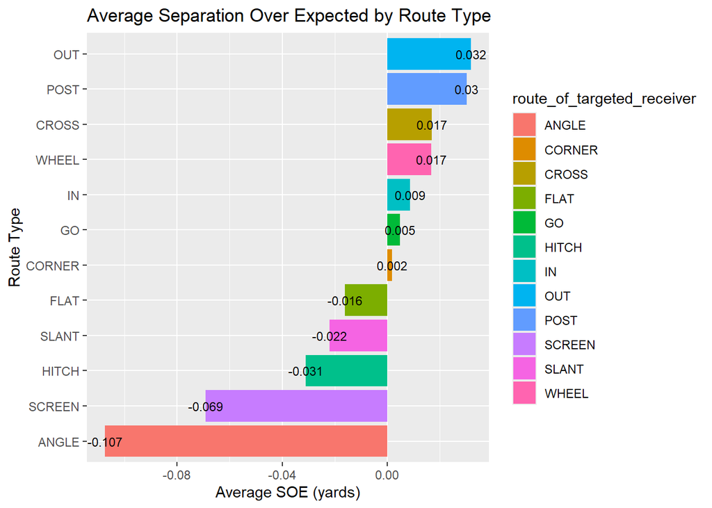

```r
route_summary_for_ggplot = test_df %>%
  group_by(route_of_targeted_receiver)%>%
  summarize(
    mean_SOE = mean(SOE),
    meidan_SOE = median(SOE),
    count = n()
  ) %>% arrange(desc(mean_SOE))

ggplot(route_summary_for_ggplot, aes(x = reorder(route_of_targeted_receiver, mean_SOE), y = mean_SOE,
                                     fill = route_of_targeted_receiver))+
  geom_col()+
  geom_text(aes(label = round(mean_SOE, 3)), size = 3)+
  coord_flip()+
  labs(
    title = "Average Separation Over Expected by Route Type",
    x = "Route Type",
    y = "Average SOE (yards)"
  )
```

After developing SOE at the frame level, we evaluate whether additional separation actually translates into productive offensive results. The following visualization tests the question in terms of expected points added.

We observe a positive relationship between SOE and EPA. Routes that generate unexpected separation tend to produce more valuable plays, captured by the upward trend in EPA as SOE increases. Although the correlation is modest, it still shows that connections in which receivers gain more separation than expected are more likely to result in receptions.

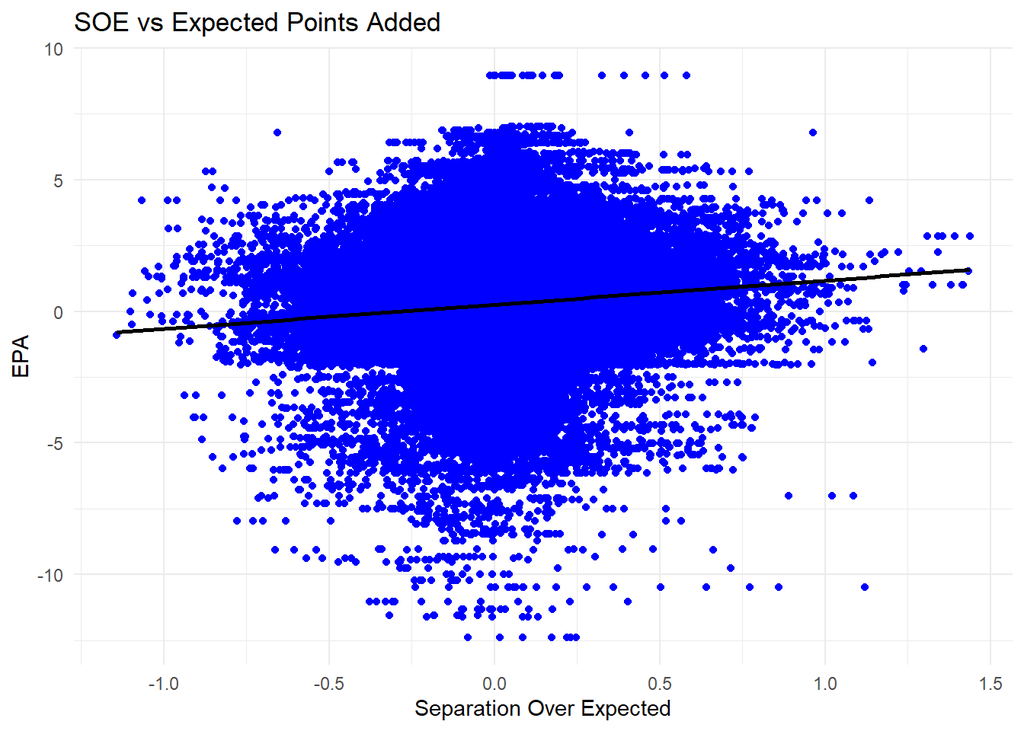

```r
ggplot(test_df, aes( x = SOE, y = expected_points_added))+
  geom_point(color = "blue")+
  geom_smooth(method = "lm", color = "black")+
  labs(
    title = "SOE vs Expected Points Added",
    x = "Separation Over Expected",
    y = "EPA"
  )+theme_minimal()
```

Together, these results show that SOE is not a universal indicator of play success, but a measure of whether a receiver creates value through physical separation rather than scheme or timing. EPA improves as SOE increases, especially for longer developing routes where separation is a must. As a result, SOE is most valuable when used to isolate individual route functionality, rather than to judge total play quality.

### Catch Probability Modeling Based on SOE

We now attempt to compute catch probability based on our newly created SOE metric and previously mentioned features of interest.

Preparing SOE Data frame for Catch Probability Model:

After creating a new data frame with expected separation and SOE, we need to prepare this data frame so that it can be used to train our catch probability model.

This involves changing the pass result outcomes (`C` for Completed Catch, `I` for In completion, and `IN` for Interception) to binary outcomes (0 for a Incomplete Pass or an Interception and 1 for a Completed Pass).

```r
SOE_df <- test_df %>%
  mutate(pass_result = case_when(
    pass_result == "C" ~ 1,
    pass_result == "I" ~ 0,
    pass_result == "IN" ~ 0
  ))
```

```r
### Building Catch Probability Model
catch_prob_label = SOE_df$pass_result
catch_prob_features = c("lag_sep", "lag_x", "lag_y", "lag_receiver_x", "lag_receiver_y",
             "lag_db_x", "lag_db_y", "lag_receiver_s", "lag_receiver_a",
             "lag_receiver_o", "lag_receiver_dir", "lag_db_s", "lag_db_a",
             "lag_db_o", "lag_db_dir", "expected_separation", "SOE")

catch_prob_matrix = as.matrix(SOE_df[,catch_prob_features])

set.seed(479)
catch_prob_model = xgboost(
  data = catch_prob_matrix,
  label = catch_prob_label,
  nrounds = 500,
  eta = 0.05,
  max_depth = 6,
  verbose = 0,
  objective = "binary:logistic"
)
```

Here we append time invariant variables from the supplementary data frame to the catch probability model to conduct further analysis.

After building our catch probability model, we use it to predict catch probabilities for frames for plays from weeks 1-18. We also evaluate the correlation between catch probability and expected separation to get a snapshot of the relationship.

```r
### Building Catch Prob DF (Frames from plays from Weeks 1-18)
catch_prob_df <- SOE_df %>%
  mutate(catch_prob = predict(catch_prob_model, catch_prob_matrix, type = "binary:logistic"))

cor(catch_prob_df$expected_separation, catch_prob_df$catch_prob)
```

```
## [1] 0.6566685
```

```r
supplementary_for_catch_df = Supplementary %>%
  select(
    game_id, play_id,
    season, game_date, game_time_eastern,
    home_team_abbr, visitor_team_abbr,
    quarter, game_clock,
    play_description,
    team_coverage_man_zone,
    team_coverage_type
  )

catch_prob_df = catch_prob_df %>%
  left_join(supplementary_for_catch_df, by = c("game_id", "play_id"))
catch_prob_df
```

```
## # A tibble: 138,726 × 58
##       game_id play_id frame_id receiver_id receiver_name receiver_position
##         <dbl>   <dbl>    <dbl>       <dbl> <chr>         <chr>
##  1 2023090700     101        2       44930 Josh Reynolds WR
##  2 2023090700     101        3       44930 Josh Reynolds WR
##  3 2023090700     101        4       44930 Josh Reynolds WR
##  4 2023090700     101        5       44930 Josh Reynolds WR
##  5 2023090700     101        6       44930 Josh Reynolds WR
##  6 2023090700     101        7       44930 Josh Reynolds WR
##  7 2023090700     101        8       44930 Josh Reynolds WR
##  8 2023090700     101        9       44930 Josh Reynolds WR
##  9 2023090700     101       10       44930 Josh Reynolds WR
## 10 2023090700     101       11       44930 Josh Reynolds WR
## # ℹ 138,716 more rows
## # ℹ 52 more variables: receiver_x <dbl>, receiver_y <dbl>,
## #   route_of_targeted_receiver <chr>, yards_gained <dbl>,
## #   expected_points_added <dbl>, pass_result <dbl>, down <dbl>,
## #   yards_to_go <dbl>, db_id <dbl>, db_name <chr>, db_position <chr>,
## #   db_x <dbl>, db_y <dbl>, actual_separation <dbl>, receiver_s <dbl>,
## #   receiver_a <dbl>, receiver_o <dbl>, receiver_dir <dbl>, db_s <dbl>, …
```

To assess our model’s accuracy and variability, we created a large number of training-testing splits, and for each split, trained our model using the training data and assessed it’s accuracy on the testing data.

```r
##Set number of simulations to 10
n_sims <- 10

##Initialize RMSE and MAE vectors
test_rmse <- rep(NA, times = n_sims)
test_mae <- rep(NA, times = n_sims)
test_log <- rep(NA, times = n_sims)

##Set our training df to be 75% of the full df
n_row <- nrow(SOE_df)
n_train <- floor(0.75 * n_row)

##Create 10 training-testing splits. For each split, we train the model using the training df and make predictions on the testing dataframe.
for(r in 1:n_sims){
  set.seed(479+r)
  train_data <-
    SOE_df |>
    dplyr::slice_sample(n = n_train)
  test_data <-
    SOE_df |>
    dplyr::anti_join(y = train_data, by = c("game_id", "frame_id", "receiver_id", "play_id"))

  train_matrix <- as.matrix(train_data[,catch_prob_features])
  test_matrix <- as.matrix(test_data[,catch_prob_features])
  train_label <- train_data$pass_result

  fit <- xgboost(
  data = train_matrix,
  label = train_label,
  nrounds = 500,
  eta = 0.05,
  max_depth = 6,
  verbose = 0,
  objective = "binary:logistic"
)

##Here, we are predicting the probability that a catch is made.

  test_preds <-
   suppressWarnings(predict(object = fit,
           newdata = test_matrix,
           type = "binary:logistic"))

  test_data$test_probs <- test_preds

##Compute RMSE/MAE on testing sets and store the values in the testing RMSE/MAE vectors.
  test_rmse[r] <-
    rmse(test_data$pass_result, test_data$test_probs)
  test_mae[r] <-
    mae(test_data$pass_result, test_data$test_probs)
  test_log[r] <-
    logLoss(catch_prob_df$pass_result, catch_prob_df$catch_prob)
}
```

```r
## Print out the average of RMSE and MAE over 10 splits.
cat("Dist testing rmse:", round(mean(test_rmse), digits = 3), "\n")
```

```
## Dist testing rmse: 0.405
```

```r
cat("Dist testing mae:", round(mean(test_mae), digits = 3), "\n");
```

```
## Dist testing mae: 0.345
```

```r
cat("Dist testing Log-Loss", round(mean(test_log), digits = 3), "\n")
```

```
## Dist testing Log-Loss 0.459
```

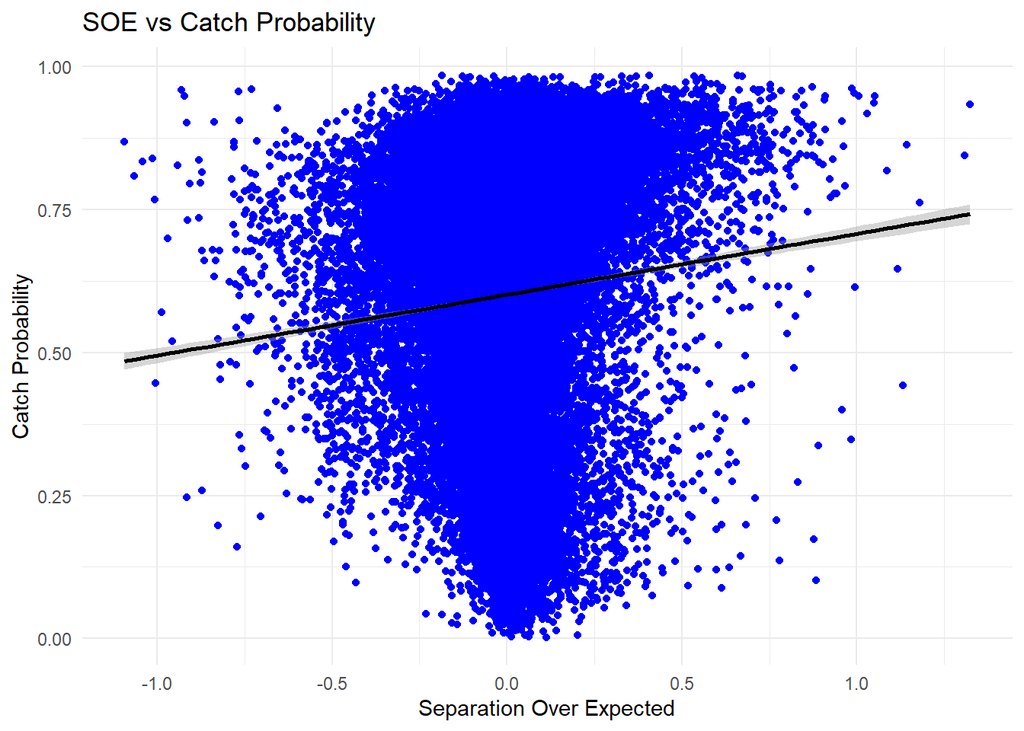

```r
ggplot(test_data, aes(x = SOE, y = test_probs))+
  geom_point(color = "blue") +
  geom_smooth(method = "lm", color = "black")+
  labs(
    title = "SOE vs Catch Probability",
    x = "Separation Over Expected",
    y = "Catch Probability"
  )+theme_minimal()
```

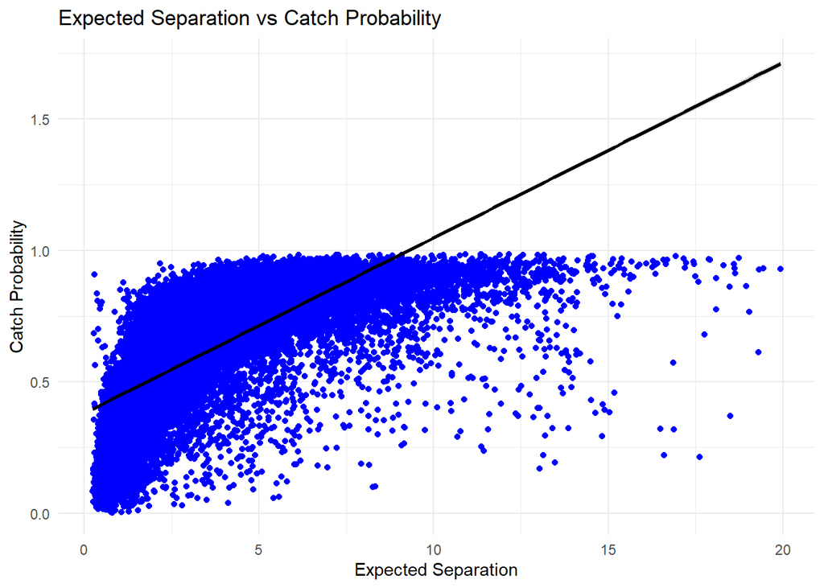

```r
ggplot(test_data %>% filter(expected_separation <= 20), aes(x = expected_separation, y = test_probs))+
  geom_point(color = "blue") +
  geom_smooth(method = "lm", color = "black")+
  labs(
    title = "Expected Separation vs Catch Probability",
    x = "Expected Separation",
    y = "Catch Probability"
  )+theme_minimal()
```

```r
cor(catch_prob_df$SOE, catch_prob_df$catch_prob)
```

```
## [1] 0.0826446
```

SOE also broken down based on defensive coverage schemes.

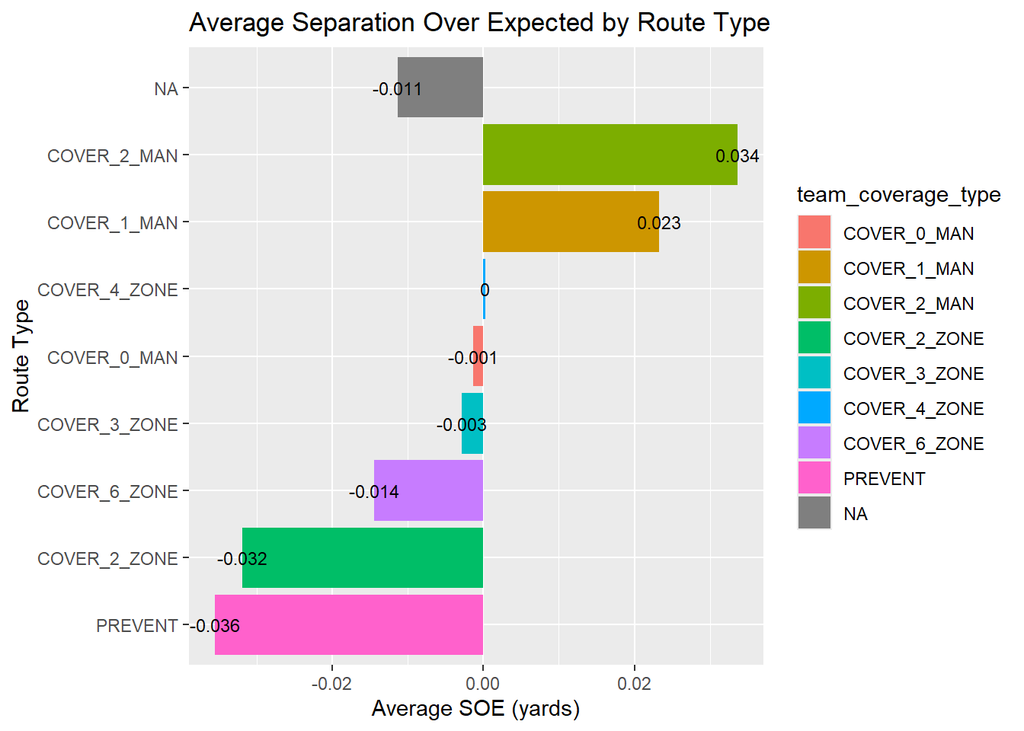

```r
catch_prob_df_defense_grouped = catch_prob_df %>%
  group_by(team_coverage_type)%>%
  summarize(
    mean_SOE = mean(SOE),
    meidan_SOE = median(SOE),
    count = n()
  ) %>% arrange(desc(mean_SOE))

ggplot(catch_prob_df_defense_grouped, aes(x = reorder(team_coverage_type, mean_SOE), y = mean_SOE,
                                     fill = team_coverage_type))+
  geom_col()+
  geom_text(aes(label = round(mean_SOE, 3)), size = 3)+
  coord_flip()+
  labs(
    title = "Average Separation Over Expected by Route Type",
    x = "Route Type",
    y = "Average SOE (yards)"
  )
```

### Visualization

To enhance the practicality of our models and direct their results in a digestible manner towards those without a data-science background, animation techniques were employed to overlay the relationship between SOE and the related Catch Probability model for each play. One of the main goals of this visualization was to provide a tool that could be employed during replays, highlighting at which points in the route separation over expected was maximized as well as its relationship with catch probability at specific points in the route. This visualization tool drew heavy inspiration from statistics shown during replays from Next Gen Stats.

To enhance the effect of the visualization, we include relevant markings on the football field.

```r
add_field_markings = function(){

  # Yard lines (every 5 yards)
  yard_lines = tibble(
    x = seq(10, 110, by = 5)
  )

  # Hash marks
  hash_marks = tibble(
    x = rep(seq(10, 110, by = 1), 2),   # no hashes in end zones
    y = c(rep(23.625, 101), rep(29.675, 101))  # left/right hashes
  )

  # Side lines around whole field, 4 entries per vector because 4 lines
  side_lines = tibble(
    x = c(0,0,120,120),
    xend = c(120,120,0,0),
    y = c(0,53.3,0,53.3),
    yend = c(0,53.3,0,53.3)
  )


   # End Zone Lines
   end_zone_lines = tibble(
    x = c(0, 120),
    xend = c(0, 120),
    y = c(0, 53.3),
    yend = c(53.3, 0)
  )

   # Separate Thick line for Goal Line
   goal_line_lines = tibble(
     x = c(10, 110),
     xend = c(10, 110),
     y = c(0, 53.3),
     yend = c(53.3, 0)
   )

  list(
    geom_segment(data = yard_lines,
                 aes(x = x, xend = x, y = 0, yend = 53.3),
                 color = "black", linewidth = 0.3, alpha = 0.5),

    geom_segment(data = hash_marks,
                 aes(x = x, xend = x,
                     y = y - 0.3,
                     yend = y + 0.3),
                 color = "black", linewidth = 0.4),

    geom_segment(data = side_lines,
                 aes(x = x, xend = xend, y = y, yend = yend),
                 color = "black", linewidth = 0.8),

    geom_segment(data = end_zone_lines,
                 aes(x = x, xend = xend, y = y, yend = yend),
                 color = "black", linewidth = 0.8),

    geom_segment(data = goal_line_lines, aes(x = x, xend = xend, y = y, yend = yend), color = "black", linewidth = 0.8),


    # Top and Bottom yard lines
    geom_text(data = yard_lines %>% filter(x %% 10 == 0, x > 10, x < 110), aes(x = x, y = 41, label = ifelse(x <= 60, x - 10, 110 - x)), size = 7, color = "white"),

    geom_text(data = yard_lines %>% filter(x %% 10 == 0, x > 10, x < 110), aes(x = x, y = 10, label = ifelse(x <= 60, x - 10, 110 - x)), size = 7, color = "white")

  )
}
```

Frame-by-frame animation that maps SOE and Catch Probability at each individual frame is created as a function of both game_id and play_id, as each play was given a unique identifier for each week. When all the input/output frames were merged this identify ability was lost.

```r
visualize_play_animated = function(play_id_, game_id_){
  df = catch_prob_df %>%
    filter(play_id == play_id_, game_id == game_id_)%>%
    arrange(frame_id)
  if (nrow(df) == 0){
    stop("No rows found for that play_id in test_data_frame.")
  }

   play_title = paste0(
    "Play", play_id_, "|",
    df$home_team_abbr[1], "vs" , df$visitor_team_abbr[1],
    "| Q", df$quarter[1], " ", df$game_clock[1]
  )

  play_subtitle = df$play_description[1]
    animation_plot = ggplot(df) +

    add_field_markings() +

    geom_path(aes(x = receiver_x, y = receiver_y, group = receiver_id),
              alpha = 0.25) +

    geom_point(aes(x = receiver_x, y = receiver_y,
                   color = SOE,
                   size = catch_prob),
               alpha = 0.9) +

    geom_point(aes(x = db_x, db_y), color = "black", size = 5) +

    geom_segment(aes(x = receiver_x, y = receiver_y, xend = db_x, yend = db_y), color = "black", alpha = 0.5) +
    scale_color_gradient2(low = "red", mid = "yellow", high = "green", name = "SOE") +

    scale_size(range = c(3,10), name = "Catch Probability") +

    coord_fixed(xlim = c(0,120), ylim = c(0,55)) +

    labs(title = play_title,
         subtitle = paste0(play_subtitle, "\nFrame:{closest_state}"),
         x = "Raw X Coordinate Yardline",
         y = "Raw Y Coordinate Yardline") +

    theme(
    panel.grid.major = element_blank(),
    panel.grid.minor = element_blank(),
    panel.background = element_rect(fill = "lightgreen")
      ) +

    transition_states(
      frame_id, state_length = 2, transition_length = 0.5) +

    geom_text(aes(x = receiver_x, y = receiver_y,
                  label = round(SOE, 2)),
              vjust = -1, size = 3) +

    geom_text(aes(x = receiver_x, y = receiver_y,
                  label = sprintf("CP: %.2f", catch_prob)),
              vjust = 1.8, size = 3, color = "blue") +

    geom_text(aes(x = receiver_x, y = receiver_y,
                  label = receiver_name),
              vjust = 1.8, size = 3, color = "blue") +

    geom_text(aes(x = db_x, y = db_y,
                  label = db_name),
              vjust = 1.8, size = 3)

    animate(animation_plot, nframes = length(unique(df$frame_id)),
          width = 1000, height = 500, renderer = gganimate::gifski_renderer(), fps = 5, )
}
```

```r
love_reed = visualize_play_animated(654, 2023123114)
```

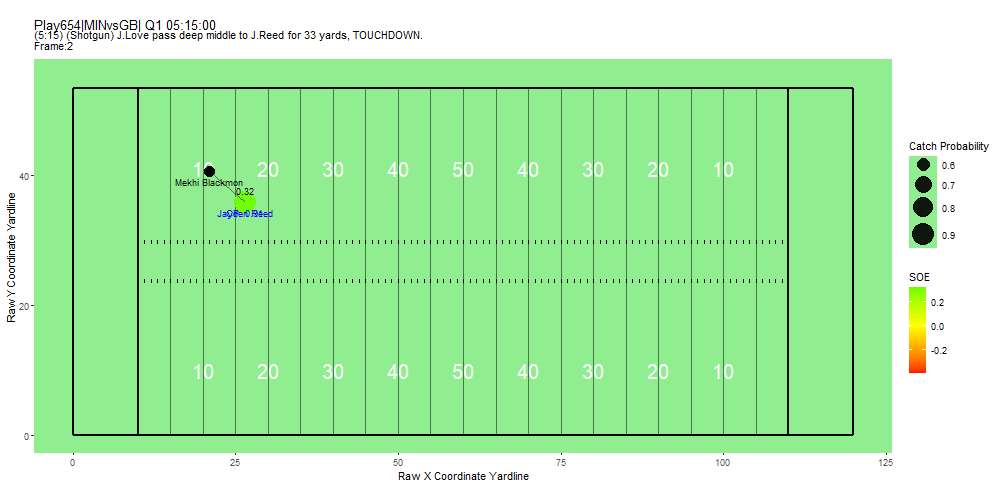

```r
anim_save("love_reed.gif", love_reed)
```

### Limitations

Our analysis showed only slight Correlation between SOE and Catch Probability, SOE and EPA. Although there seems to be a positive relationship between catch probability, as well as SOE and EPA, the relationship itself is not large in size, suggesting that SOE only slightly influences outcomes. However, hypothesis testing on the correlation coefficient suggests that this relationship is not due to chance.

```r
cor(catch_prob_df$SOE, catch_prob_df$catch_prob)
```

```
## [1] 0.0826446
```

```r
cor(catch_prob_df$SOE, catch_prob_df$expected_points_added)
```

```
## [1] 0.1008216
```

```r
cor.test(catch_prob_df$SOE, catch_prob_df$catch_prob, method = "pearson")
```

```
##
##  Pearson's product-moment correlation
##
## data:  catch_prob_df$SOE and catch_prob_df$catch_prob
## t = 30.887, df = 138724, p-value < 2.2e-16
## alternative hypothesis: true correlation is not equal to 0
## 95 percent confidence interval:
##  0.07741603 0.08786861
## sample estimates:
##       cor
## 0.0826446
```

```r
cor.test(catch_prob_df$SOE, catch_prob_df$expected_points_added, method = "pearson")
```

```
##
##  Pearson's product-moment correlation
##
## data:  catch_prob_df$SOE and catch_prob_df$expected_points_added
## t = 37.744, df = 138724, p-value < 2.2e-16
## alternative hypothesis: true correlation is not equal to 0
## 95 percent confidence interval:
##  0.09561014 0.10602762
## sample estimates:
##       cor
## 0.1008216
```

SOE could also be represented in more than one defender. Instead of recording only the minimum distance between a receiver and a singular defender, SOE could potentially be extended to a neighborhood of defenders, as double coverage and zone defense situations where multiple defenders are playing a specific receiver. If extended as such, SOE could further represent how receivers create space under tight conditions. Extending this logic further, SOE does not account for route combinations of other receivers on the field, which of course influence where the other defenders on the field end up.

SOE is also reflected uniformly across all points in the route. However, separation matters most when the ball is close to the receiver of interest, as being open doesn’t matter nearly as much when the ball is nowhere close to the receiver or not released yet. Therefore, it makes sense to develop a way to value SOE when the ball is close to the receiver or caught at the end of a route. Such a method can be generalized as such.

$$Weighted \space SOE = W_d *
SOE_t$$
where $W_d$ is the the weight function based on distance from the ball to the receiver, and $SOE_t$ is simply the SOE at a time t. To compute SOE over the course of a route, which values separation at the balls point of arrival can be modeled as such.

$$Total \space SOE = \sum_tW_d *
SOE_t$$

$W_d$ could likely be some exponential decay/weighting function, as the value of being open when the ball arrives is likely in non-linear fashion.

The following graph illustrates the issue with failing to weight SOE, as the figure suggests a negative association between unexpected separation at the end of a route and the probability that a catch is made. Intuitively this makes little sense, as if a receiver is open more than they should be at a given point, they should be more likely to catch the pass assuming its on target.

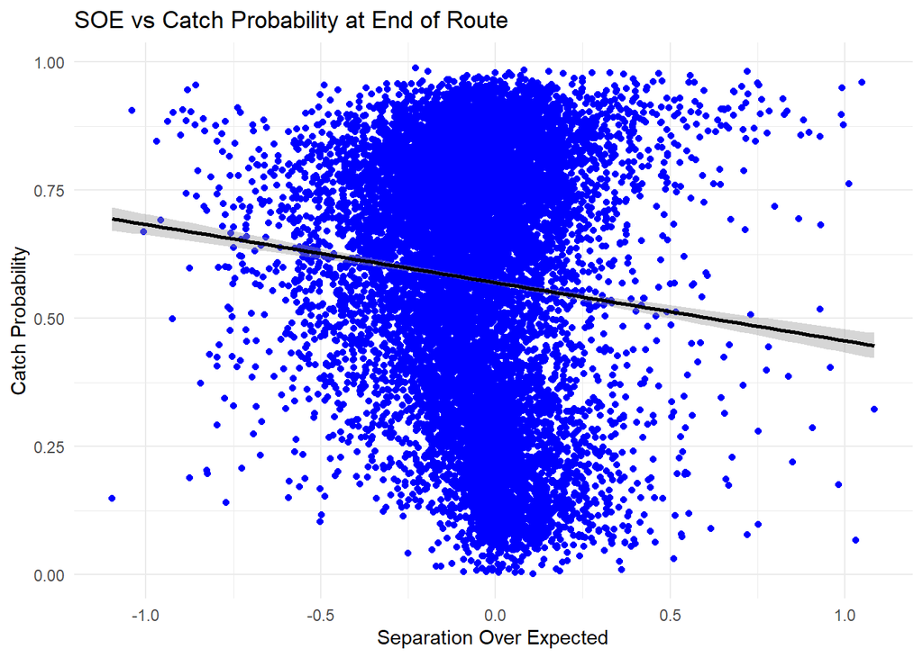

```r
sample_df = catch_prob_df %>% group_by(play_id, week) %>% slice_max(frame_id)
ggplot(sample_df, aes(x = SOE, y = catch_prob)) + geom_point(color = "blue") +
  geom_smooth(method = "lm", color = "black")+
  labs(
    title = "SOE vs Catch Probability at End of Route",
    x = "Separation Over Expected",
    y = "Catch Probability"
  ) +theme_minimal()
```

### Conclusions and Future Considerations

This initial development of a Separation Over Expected (SOE) metric offers promising evidence that unexpected receiver movement — separation beyond what the play context predicts — meaningfully contributes to play success. While the identified effects are currently modest, they demonstrate that SOE captures signal beyond raw distance alone and can surface hidden receiver skill that raw player separation misses.

However, SOE in its current form is still a generalized, frame-level measure. To fully unlock its value, future variations of the metric should target when and how separation is generated. A weighted SOE approach could better distinguish and rank players who create separation when it matters most, making it worthwhile to produce route-level summaries that enable reliable comparison and ranking of receivers. These weighted summaries may help quantify route running skills such as timing, deception, and spatial awareness.

Extending SOE to a more Granular analysis throughout a route could further reveal if separation is achieved at the break point, release, or while the ball is in flight — and whether the driver of that change is primarily offensive movement or defensive missteps. Perhaps decomposing these results via another classification model would help describe receiver movement even further.

A Bayesian modeling extension may also provide meaningful advancements by incorporating uncertainty into separation predictions, while also allowing for the idea of establishing priors about the route and information that occurred before each frame. Such an approach would integrate information across prior frames and contextual priors for route types, coverage, and leverage, strengthening interpret ability and robustness.

Ultimately, SOE offers a solid foundation for measuring receiver effectiveness in unexpected player movement. With some refinement, it has potential to grow beyond the replay value we’ve used it in and become a powerful tool for coaching evaluation, defensive game-planning, player development, and roster decision-making.